# MSDS 6371 Project 1: Hospital Stay MLR

Tracy Dower & Blake Armstrong

### Dataset & Objectives

The team chose to analyze the provided dataset of hospital data that contains 11 predictors collected from 113 different hospitals. There are two main objectives here that the team has set out to solve that we have outlined below:

**Objective 1:** This analysis is to determine whether a hospital’s **infection risk** is significantly associated with the **average length** of patient stay, after accounting for other potentially influential factors. Using data from 113 hospitals—including variables such as patient age, number of nurses, hospital utilization, number of beds, and frequency of routine medical checks—we will construct a regression model to evaluate the impact of infection risk and related factors on hospital stay duration.

1. A more **complex Multiple Linear Regression (MLR)** model that includes added features or interactions.

[output not shown]

### Exploratory Data Analysis (EDA)

In EDA we attempt to visually identify trends and such that we can verify important insights and assumptions about the data. This process involves summarizing the main characteristics of a dataset, often using visual methods such as histograms, boxplots, scatter plots, and correlation matrices. EDA helps uncover underlying patterns, spot anomalies or outliers, test assumptions, and check the quality of the data. It is a crucial first step before applying any formal modeling techniques, as it guides data cleaning, feature selection, and the choice of analytical methods.

First we want to upload the data and determine if there are any missing variables that we need to account for. From the chart, it looks like the dataset we were provided is not missing any data points, and the corresponding variable summaries and value histograms can be observed as well:

Data summary

| Name | skim.hospital |
| --- | --- |
| Number of rows | 113 |
| Number of columns | 12 |
| _______________________ |  |
| Column type frequency: |  |
| numeric | 12 |
| ________________________ |  |
| Group variables | None |

**Variable type: numeric**

| skim_variable | n_missing | complete_rate | mean | sd | p0 | p25 | p50 | p75 | p100 | hist |
| --- | --- | --- | --- | --- | --- | --- | --- | --- | --- | --- |
| ID | 0 | 1 | 57.00 | 32.76 | 1.0 | 29.00 | 57.00 | 85.00 | 113.00 | ▇▇▇▇▇ |
| Length of Stay | 0 | 1 | 9.65 | 1.91 | 6.7 | 8.34 | 9.42 | 10.47 | 19.56 | ▇▇▁▁▁ |
| Age | 0 | 1 | 53.23 | 4.46 | 38.8 | 50.90 | 53.20 | 56.20 | 65.90 | ▁▂▇▃▁ |
| Infection Risk | 0 | 1 | 4.35 | 1.34 | 1.3 | 3.70 | 4.40 | 5.20 | 7.80 | ▂▃▇▃▁ |
| Routine Culturing Ratio | 0 | 1 | 15.79 | 10.23 | 1.6 | 8.40 | 14.10 | 20.30 | 60.50 | ▇▆▂▁▁ |
| Routine Chest X-Ray Ratio | 0 | 1 | 81.63 | 19.36 | 39.6 | 69.50 | 82.30 | 94.10 | 133.50 | ▃▅▇▃▁ |
| No. of Beds | 0 | 1 | 252.17 | 192.84 | 29.0 | 106.00 | 186.00 | 312.00 | 835.00 | ▇▅▂▁▁ |
| Med School Affiliation | 0 | 1 | 1.85 | 0.36 | 1.0 | 2.00 | 2.00 | 2.00 | 2.00 | ▂▁▁▁▇ |
| Region | 0 | 1 | 2.36 | 1.01 | 1.0 | 2.00 | 2.00 | 3.00 | 4.00 | ▆▇▁▇▃ |
| Average Patients | 0 | 1 | 191.37 | 153.76 | 20.0 | 68.00 | 143.00 | 252.00 | 791.00 | ▇▃▂▁▁ |
| Average Full Time Nurses | 0 | 1 | 173.25 | 139.27 | 14.0 | 66.00 | 132.00 | 218.00 | 656.00 | ▇▅▂▁▁ |
| Percent Facility Utilization | 0 | 1 | 43.16 | 15.20 | 5.7 | 31.40 | 42.90 | 54.30 | 80.00 | ▁▆▇▆▂ |

Next, we want to look for trends between our response variable and the predictor variables:

**Linear-Linear Plots:** From the plots below, there looks to be decent clustering in a couple of the plots therefore we will explore transforming them to see how trends change. Additionally, two predictors, “Med School Affiliation” and “Region” could be treated as categorical variables, however there is an observed trend in Region that we would consider not treating it as such.

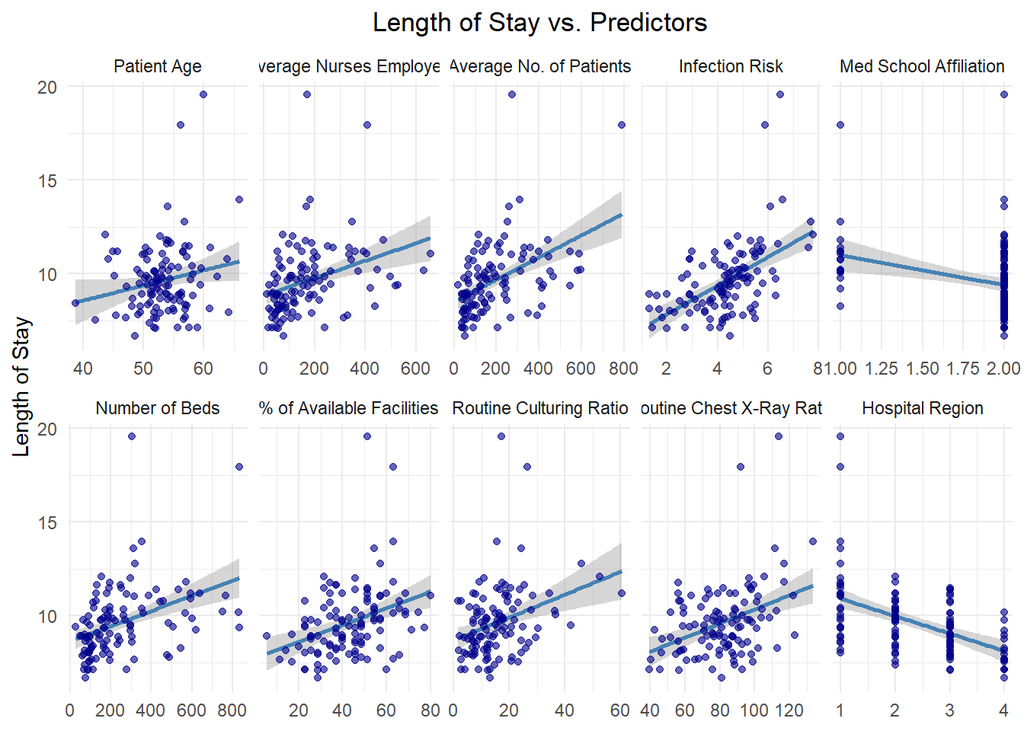

**Log-Linear Plots:** In these plots, we logged the response variable “Length of Stay” vs. the rest of the parameters, and didn’t notice any change in distributions of the charts.

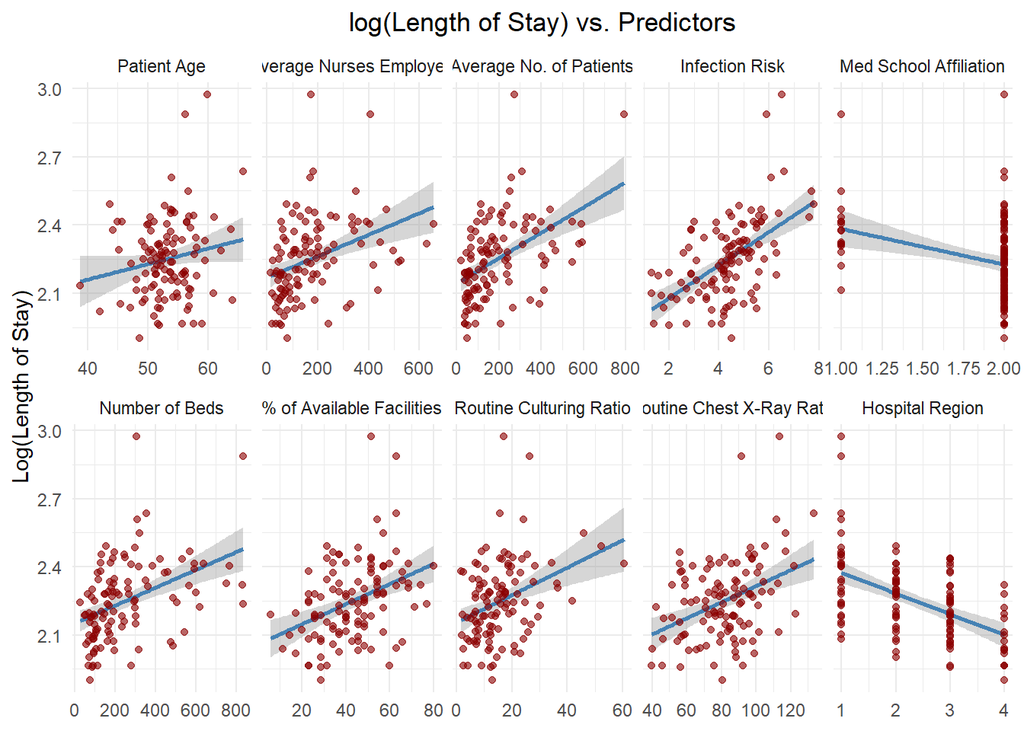

**Linear-Log Plots:** In these, we logged the predictor variables except for the two variables “Med School Affiliation” and “Region” since they didn’t have distributions that required it. In these plots we can observe more of a linear trend forming between a majority, if not all predictors. We will analyze the models using these logged predictors.

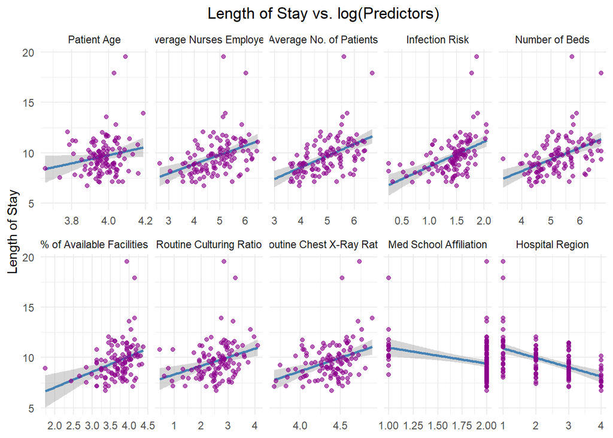

**Log-Log Plots:** These plots don’t appear to exhibit a different trend from the Linear-Log, and therefore we won’t utilize the log-log for Objective 1 since we will lose inference on the mean.

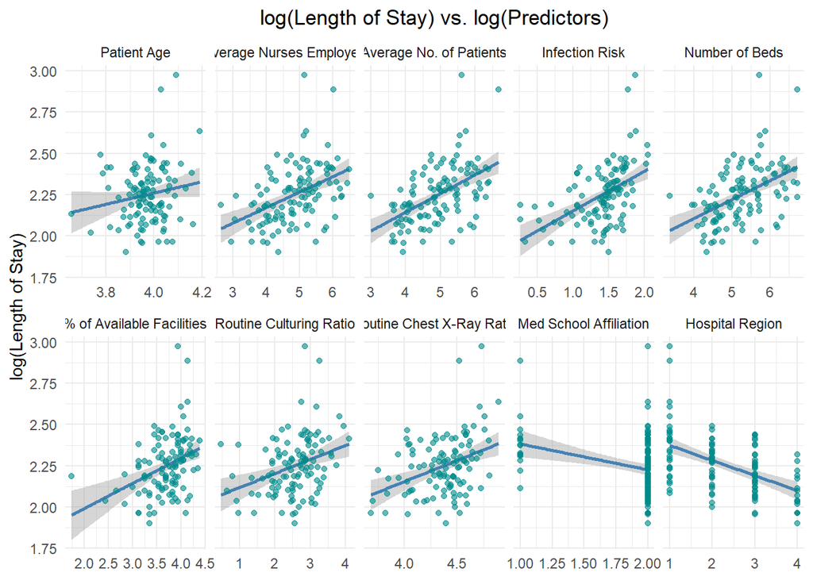

## Objective 1: Avg. Length of Stay vs. Infection Risk

As stated previously in the introduction, the goal of Objective 1 is to determine whether a hospital’s **infection risk** is significantly associated with the **average length** of patient stay, after accounting for other potentially influential factors.

First we created a model with all of the non-transformed variables to statistically confirm relationships that we saw in the graphs previously when holding all other predictors constant.

| **Characteristic** | **Beta** | **95% CI** | **p-value** | **VIF** |
| --- | --- | --- | --- | --- |
| (Intercept) | 3.406 | -0.423, 7.236 | 0.081 |  |
| ID | 0.003 | -0.004, 0.011 | 0.419 | 1.2 |
| Age | 0.085 | 0.031, 0.140 | 0.002 | 1.1 |
| Inf.Risk | 0.431 | 0.184, 0.679 | <0.001 | 2.1 |
| R.Cul.Rat | 0.010 | -0.022, 0.041 | 0.539 | 2.0 |
| R.CX.ray.Rat | 0.013 | -0.001, 0.027 | 0.076 | 1.4 |
| N.Beds | -0.005 | -0.012, 0.002 | 0.124 | 34 |
| Med.Sc.Aff | -0.177 | -1.034, 0.680 | 0.683 | 1.8 |
| Region | -0.583 | -0.846, -0.321 | <0.001 | 1.3 |
| Avg.Pat | 0.016 | 0.007, 0.024 | <0.001 | 33 |
| Avg.Nur | -0.005 | -0.010, -0.001 | 0.016 | 7.2 |
| Pct.Ser.Fac | -0.012 | -0.039, 0.015 | 0.366 | 3.2 |

Abbreviations: CI = Confidence Interval, VIF = Variance Inflation Factor

AIC of no transformation predictors:

```
## [1] 379.8434
```

**Model 1 Linear Predictors RMSE:**

[output not shown]

Similar to the linear-linear plots we can see clustering on the lower range of x-values for a majority of the predictors, which indicates that the transformations we contemplated could be necessary.

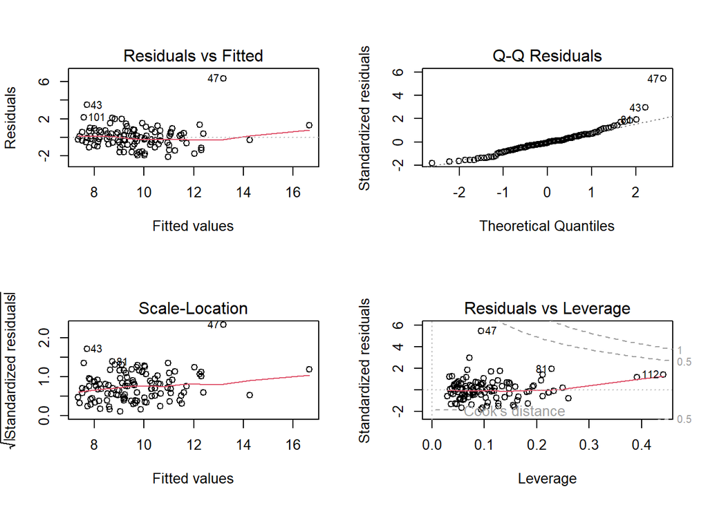

Next we ran a model with the logged predictors to determine if the observed higher linear trend were more statistically significant when holding all other parameters constant. what we found is that the AIC for this model is higher than the linear-linear model.

| **Characteristic** | **Beta** | **95% CI** | **p-value** | **VIF** |
| --- | --- | --- | --- | --- |
| (Intercept) | -18.817 | -32.303, -5.330 | 0.007 |  |
| log_Age | 5.198 | 2.180, 8.216 | <0.001 | 1.1 |
| log_Inf.Risk | 1.685 | 0.608, 2.762 | 0.002 | 2.6 |
| log_R.Cul.Rat | -0.029 | -0.556, 0.499 | 0.914 | 2.3 |
| log_R.CX.ray.Rat | 1.194 | 0.008, 2.380 | 0.048 | 1.5 |
| log_N.Beds | -0.260 | -2.140, 1.620 | 0.784 | 32 |
| log_Avg.Pat | 2.078 | 0.447, 3.709 | 0.013 | 29 |
| log_Avg.Nur | -0.959 | -1.910, -0.009 | 0.048 | 11 |
| log_Pct.Ser.Fac | -0.682 | -1.765, 0.400 | 0.214 | 3.5 |
| Region | -0.614 | -0.890, -0.338 | <0.001 | 1.3 |

Abbreviations: CI = Confidence Interval, VIF = Variance Inflation Factor

AIC of logged predictors model:

```r
AIC(model2)
```

```
## [1] 391.9772
```

**Model 2 Logged Predictors RMSE:**

[output not shown]

As you can see from these residuals they are more random and more of a random point cloud and less clustered.

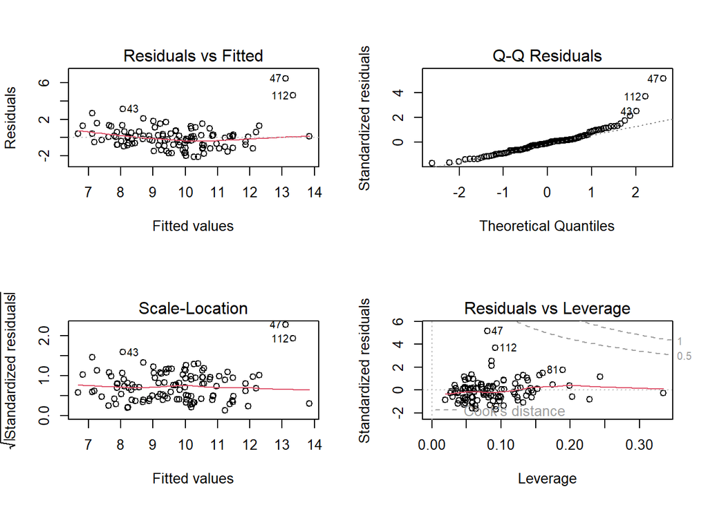

## Automatic Feature Selection

**Feature Selection of Linear-Linear:** The team chose to use the lasso function recently learned in MSDS 6372 to find the optimal penalty term and automatically select the predictor terms which are below:

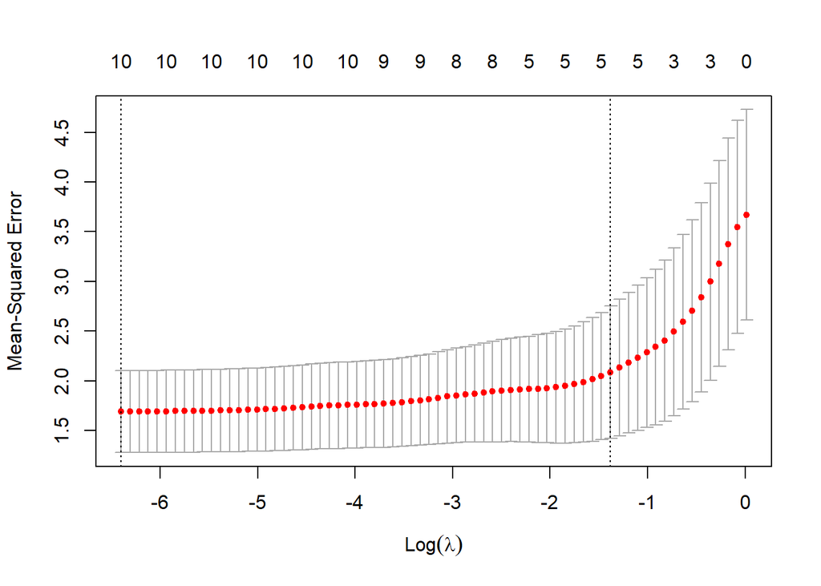

```
## 12 x 1 sparse Matrix of class "dgCMatrix"
##                        s1
## (Intercept)   6.973568147
## (Intercept)   .
## Age           0.027096097
## Inf.Risk      0.357219637
## R.Cul.Rat     .
## R.CX.ray.Rat  0.004571846
## N.Beds        .
## Med.Sc.Aff    .
## Region       -0.502366410
## Avg.Pat       0.002563316
## Avg.Nur       .
## Pct.Ser.Fac   .
```

**Automatic Feature Selection of Linear-Log:**

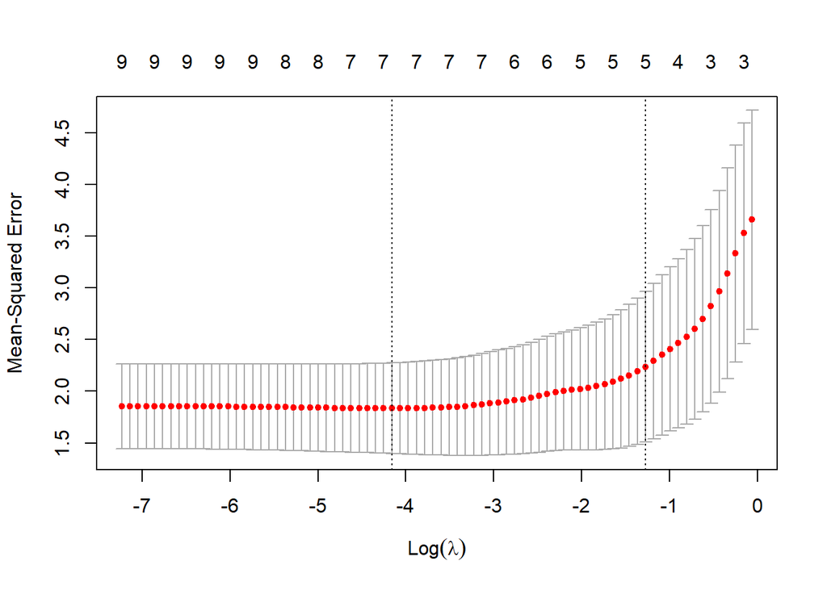

```
## 11 x 1 sparse Matrix of class "dgCMatrix"
##                          s1
## (Intercept)      -0.4116715
## (Intercept)       .
## log_Age           1.4673141
## log_Inf.Risk      0.8393495
## log_R.Cul.Rat     .
## log_R.CX.ray.Rat  0.3824166
## log_N.Beds        .
## log_Avg.Pat       0.5103366
## log_Avg.Nur       .
## log_Pct.Ser.Fac   .
## Region           -0.4860871
```

After multiple iterations and methods of feature selection on the logged and unlogged variables, they all came up with same/similar answers for statistically significant predictors. To run our final model we utilized Age, Infection Risk, Chest XRay Ratio, Average Patients (removed number of beds as these two were very highly correlated), Average Nurse Count, and the Region of the hospital.

Our final simple MLR model is as below:

## Objective 1: Final Model: Simple

**Final Parameter Table Summary:**

| **Characteristic** | **Beta** | **95% CI** | **p-value** | **VIF** |
| --- | --- | --- | --- | --- |
| (Intercept) | 3.241 | 0.104, 6.379 | 0.043 |  |
| Age | 0.079 | 0.027, 0.131 | 0.003 | 1.0 |
| Inf.Risk | 0.453 | 0.241, 0.664 | <0.001 | 1.5 |
| R.CX.ray.Rat | 0.013 | 0.000, 0.027 | 0.057 | 1.4 |
| Avg.Pat | 0.010 | 0.006, 0.013 | <0.001 | 5.8 |
| Avg.Nur | -0.007 | -0.011, -0.003 | <0.001 | 5.9 |
| Region | -0.618 | -0.860, -0.376 | <0.001 | 1.1 |

Abbreviations: CI = Confidence Interval, VIF = Variance Inflation Factor

**Residual Plots:**

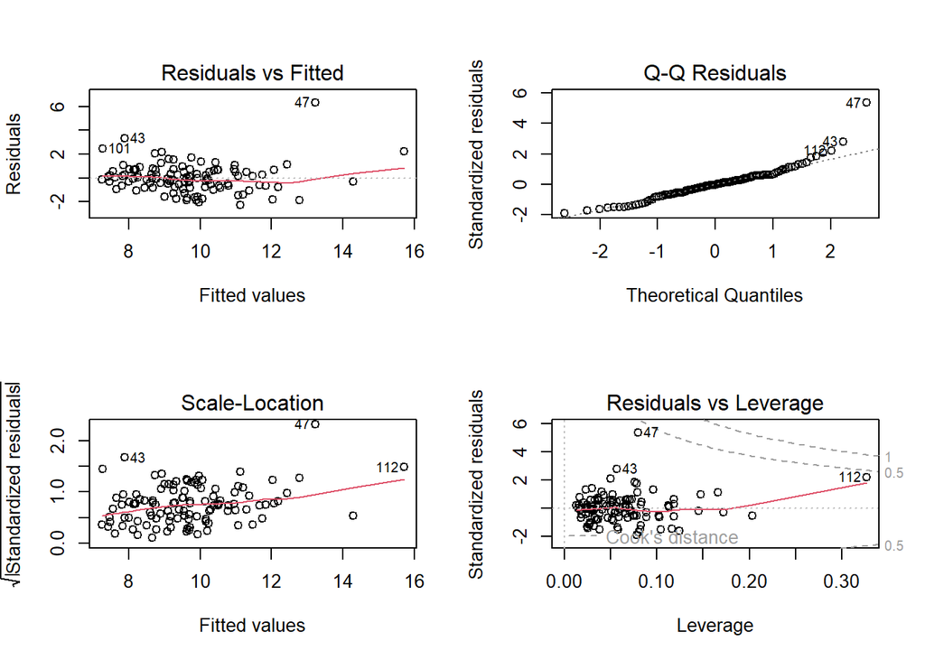

**Final Model Validation Statistics**

```
## Linear Regression
##
## 113 samples
##   6 predictor
##
## No pre-processing
## Resampling: Cross-Validated (5 fold, repeated 10 times)
## Summary of sample sizes: 90, 90, 90, 91, 91, 91, ...
## Resampling results:
##
##   RMSE      Rsquared   MAE
##   1.251457  0.5781483  0.9096127
##
## Tuning parameter 'intercept' was held constant at a value of TRUE
```

**Objective 1 Summary:** A multiple linear regression model was developed to examine the relationship between a dependent variable and six predictors: age, infection risk, chest X-ray ratio, average patient count, average nurse, and region.